# Estadística Multivariada Examen 1

Mario Becerra 124362 Felipe Domínguez 127041

05/03/2015

## Descripción de la base de datos

Los datos están relacionados con las campañas de marketing de una institución bancaria de Portugal. Abarca 17 campañas que ocurrieron entre mayo 2008 y noviembre 2010, las campañas consisten en llamadas a clientes sumando 40,690 contactos en esta base de datos. En las llamadas se ofrecía un contrato a largo plazo para invertir dinero, con tasas de interés atractivas (de acuerdo al banco). En cada contacto se registraban 16 atributos que incluyen la respuesta del cliente, esto es si el cliente contrató el producto o no.

Las variables son las siguientes:

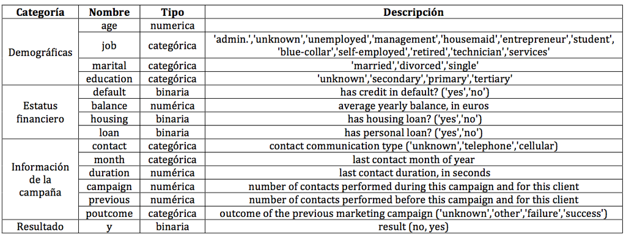

La institución bancaria quisiera conocer como están relacionadas estas variables, en particular, quisieran entender la relación con la variable respuesta y.

```r
library(dplyr)
library(ggplot2)
library(bnlearn)
library(gRain)
library(tidyr)
library(SDMTools)
load('./Datos/mkt.Rdata')
```

Dividimos la muestra en un conjunto de prueba y uno de entrenamiento.

```r
set.seed(18937)
mkt_train <- sample_n(mkt, 30000)
mkt_test <- anti_join(mkt, mkt_train)
```

Tenemos en la descripción de la base de datos que hay algunas variables numéricas. Vamos a categorizar estas variables, pues si hay pocas observaciones sobre algún número en particular, puede haber estimaciones ruidosas. Esto se puede ver gráficamente en los histogramas siguientes.

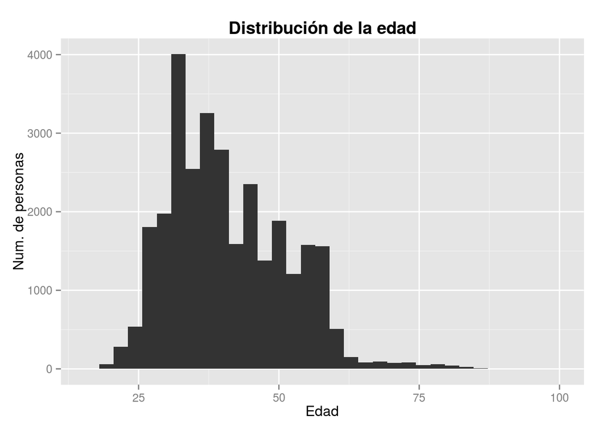

```r
qplot(mkt_train$age) +
  ggtitle("Distribución de la edad") +
  theme(plot.title = element_text(lineheight=.8, face="bold")) +
  xlab("Edad") +
  ylab("Num. de personas")
```

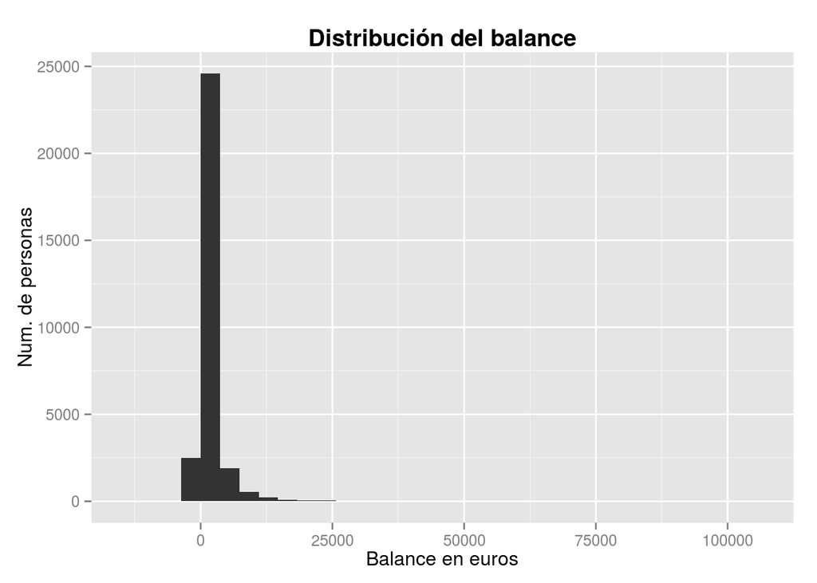

```r
qplot(mkt_train$balance) +
  ggtitle("Distribución del balance") +
  theme(plot.title = element_text(lineheight=.8, face="bold")) +
  xlab("Balance en euros") +
  ylab("Num. de personas")
```

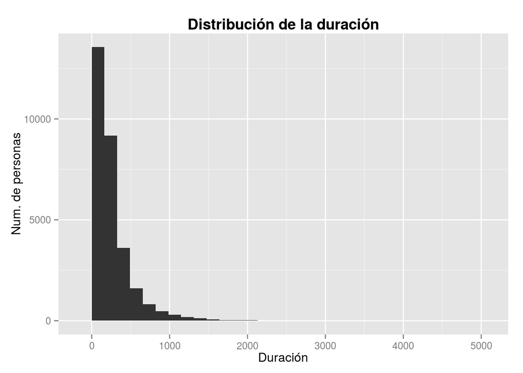

```r
qplot(mkt_train$duration) +
  ggtitle("Distribución de la duración") +
  theme(plot.title = element_text(lineheight=.8, face="bold")) +
  xlab("Duración") +
  ylab("Num. de personas")
```

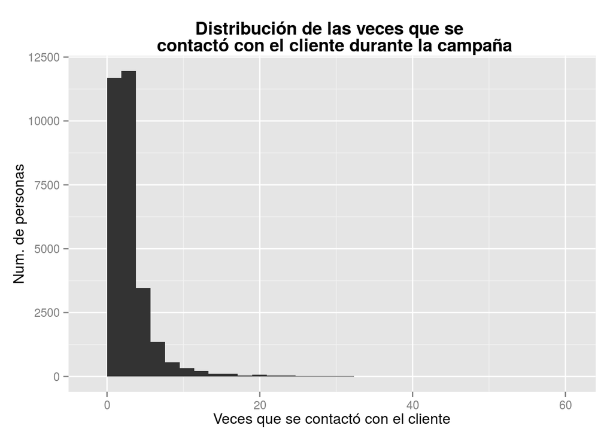

```r
qplot(mkt_train$campaign) +
  ggtitle("Distribución de las veces que se \n contactó con el cliente durante la campaña") +
  theme(plot.title = element_text(lineheight=.8, face="bold")) +
  xlab("Veces que se contactó con el cliente") +
  ylab("Num. de personas")
```

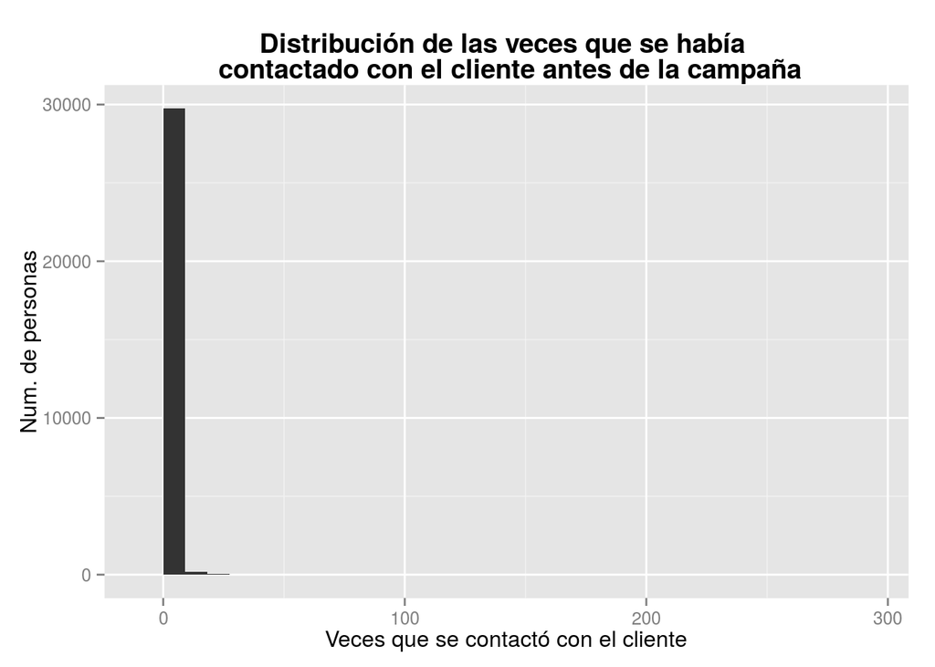

```r
qplot(mkt_train$previous) +
  ggtitle("Distribución de las veces que se había \n contactado con el cliente antes de la campaña") +
  theme(plot.title = element_text(lineheight=.8, face="bold")) +
  xlab("Veces que se contactó con el cliente") +
  ylab("Num. de personas")
```

Como se puede apreciar en los histogramas, todas las variables están sesgadas hacia algún lado y tienen valores extremos con pocas observaciones.

Para evitar esto, vamos a categorizar cada una de las variables anteriores en intervalos tales que la cantidad de clientes en cada intervalo sea más o menos igual.

```r
mkt_train$age_cat <- cut(mkt_train$age, quantile(mkt_train$age, probs=(0:15)/15))
mkt_train$balance_cat <- cut(mkt_train$balance, quantile(mkt_train$balance, probs=(0:15)/15))
mkt_train$duration_cat <- cut(mkt_train$duration, quantile(mkt_train$duration, probs=(0:5)/5))
mkt_train$campaign_cat <- cut(mkt_train$campaign, c(0,1,3,max(mkt_train$campaign)))
mkt_train$previous_cat <- factor(mkt_train$previous!=0)
train <- mkt_train[,sapply(mkt_train, class)=='factor']
names(train) <- c("job","marital","education","default","housing","loan","contact","month","poutcome","y",  "age","balance", "duration","campaign","previous")
train <- train[complete.cases(train),]
```

Vamos a aprender la estructura de una red bayesiana a partir de la muestra de entrenamiento. Debido a que la variable de interés es si contrató el plan o no ($y$), podemos considerarla como la variable respuesta, por lo que en la red bayesiana vamos a ‘obligar’ al algoritmo a que no le asigne hijos a la $y$ en la red. Ajustaremos primero dos redes con distinto *score*, una con AIC y otra con BIC.

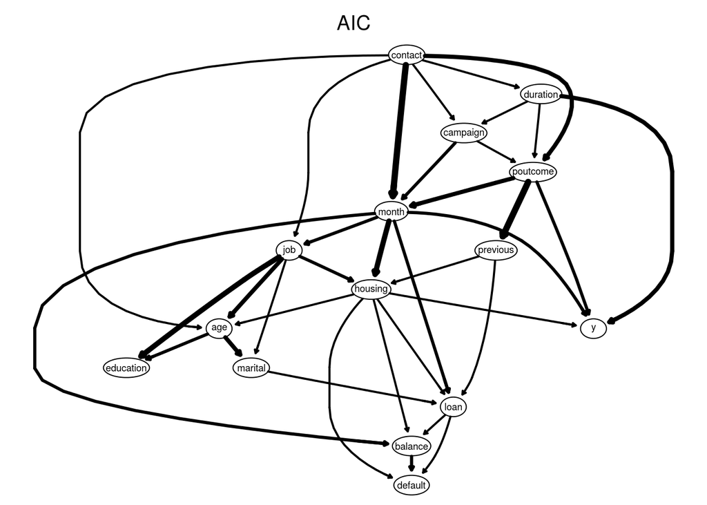

```r
black <- expand.grid('y',names(train))
net1aic <- hc(train,  score = 'aic', blacklist = black)
strength1aic <- arc.strength(net1aic, train)
strength.plot(net1aic, strength1aic, shape='ellipse', main='AIC')
```

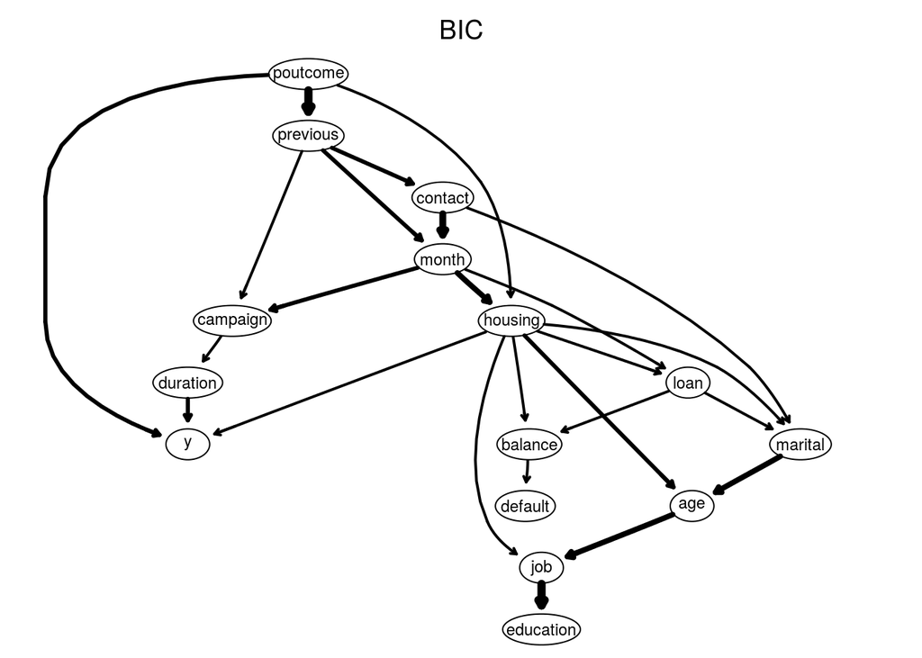

```r
net1bic <- hc(train,  score = 'bic', blacklist = black)
strength1bic <- arc.strength(net1bic, train)
strength.plot(net1bic, strength1bic, shape='ellipse', main='BIC')
```

Tal vez lo primero que salta a la vista es que con BIC hay menos relaciones que con AIC, esto debido a que el primero es más ‘estricto’ con las relaciones y deja menos relaciones espurias en el modelo.

Vemos de la red resultante del BIC que las variables que afectan directamente a $y$ son *duration*, *poutcome* y *housing*; es decir, según esta red, lo que afecta directamente a que acepten el contrato o no es el hecho de que tengan un préstamo de casa, cuánto tiempo duró la llamada de ofrecimiento del servicio y el resultado de la campaña de *marketing* anterior. Mientras que en AIC se agrega la variable la variable *month*.

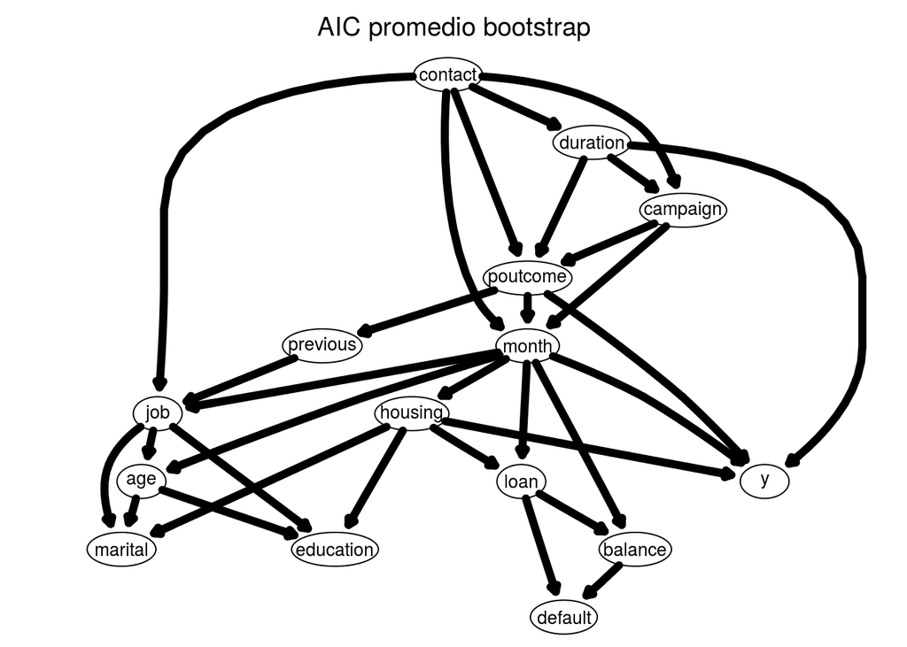

```r
net1aicboot <- boot.strength(train, R=100, algorithm='hc', algorithm.args=list(score='aic', blacklist=black), cpdag=FALSE)
net1aicavg<-averaged.network(net1aicboot, names(train), 0.8)
strength1aicavg <- arc.strength(net1aicavg, train)
strength.plot(net1aicavg, strength1aicavg, shape='ellipse', main='AIC promedio bootstrap')
```

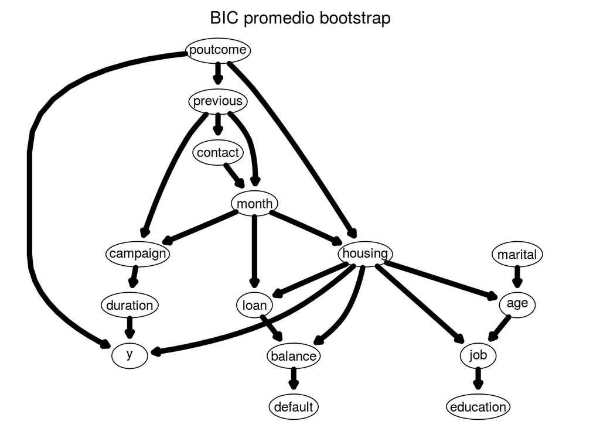

```r
net1bicboot <- boot.strength(train, R=100, algorithm='hc', algorithm.args=list(score='bic', blacklist=black), cpdag=FALSE)
net1bicavg<-averaged.network(net1bicboot, names(train), 0.8)
strength1bicavg <- arc.strength(net1bicavg, train)
strength.plot(net1bicavg, strength1bicavg, shape='ellipse', main='BIC promedio bootstrap')
```

Vemos ahora en esta nueva red que las flechas son todas más grusas, esto indica que la fuerza de los arcos es mayor ahora; y se puede ver que las variables que afectaban directamente a la $y$ no han cambiado; tanto con BIC como con AIC.

A continuación se pueden ver los arcos con fuerza igual a 1 (el máximo) para el criterio con AIC.

```r
arrange(net1aicboot[net1aicboot$strength==1,], from)
```

```
##         from        to strength direction
## 1        age       job        1      0.00
## 2        age   marital        1      1.00
## 3        age education        1      1.00
## 4        age     month        1      0.00
## 5    balance   default        1      1.00
## 6    balance      loan        1      0.46
## 7    balance     month        1      0.00
## 8   campaign   contact        1      0.17
## 9   campaign     month        1      1.00
## 10  campaign  poutcome        1      1.00
## 11  campaign  duration        1      0.00
## 12   contact     month        1      0.83
## 13   contact  duration        1      0.83
## 14   contact  campaign        1      0.83
```

[output cut: 40 more lines]

Para BIC.

```r
arrange(net1bicboot[net1bicboot$strength==1,], from)
```

```
##         from        to strength direction
## 1        age       job        1      0.93
## 2        age   marital        1      0.07
## 3    balance   default        1      0.99
## 4    balance   housing        1      0.00
## 5    balance      loan        1      0.00
## 6   campaign     month        1      0.02
## 7   campaign  duration        1      0.98
## 8    contact     month        1      0.90
## 9    default   balance        1      0.01
## 10  duration         y        1      1.00
## 11  duration  campaign        1      0.02
## 12 education       job        1      0.00
## 13   housing       job        1      0.94
## 14   housing      loan        1      1.00
```

[output cut: 16 more lines]

Como ya se había mencionado, el criterio BIC es más estricto, por lo que es natural que haya menos relaciones con fuerza igua a 1 usando BIC que usando AIC; y se puede ver que muchas de las relaciones de BIC están en AIC; de hecho, el número e elementos en la intersección de las dos tablas es 26.

Después de todo este análisis inicial de redes, decidiremos usar la red creada con el criterio del BIC, pues tiene menos relaciones, y como el objetivo final es describir el comportamiento de los clientes, no necesitamos de muchas relaciones que tal vez intuitivamente no tengan mucho sentido.

Procederemos ahora a estimar los parámetros de la red. Vamos primero a probar con máxima verosimilitud, sin ninguna especie de suavizamiento ni regularización, aunque si se observa la tabla siguiente (la cual muestra los conteos de la variable respuesta $y$ condicionada a los nodos que apuntan a ella) se nota que muy seguramente habrá estimaciones ruidosas debido a que algunas probabilidades condicionales tienen pocas observaciones.

```r
data.frame(table(train$y, train$duration, train$poutcome, train$housing))
```

```
##    Var1           Var2    Var3 Var4 Freq
## 1    no         (0,90] failure   no  147
## 2   yes         (0,90] failure   no    4
## 3    no       (90,147] failure   no  188
## 4   yes       (90,147] failure   no   22
## 5    no      (147,223] failure   no  146
## 6   yes      (147,223] failure   no   41
## 7    no      (223,370] failure   no  161
## 8   yes      (223,370] failure   no   68
## 9    no (370,4.92e+03] failure   no   89
## 10  yes (370,4.92e+03] failure   no   93
## 11   no         (0,90]   other   no   55
## 12  yes         (0,90]   other   no    1
## 13   no       (90,147]   other   no   64
## 14  yes       (90,147]   other   no    9
```

[output cut: 66 more lines]

```r
fit_mle <- bn.fit(net1bicavg, data = train, method = 'mle')
```

Ahora las probabilidades estimadas por máxima verosimilitud.

```r
probs_fit_mle <- data.frame(fit_mle[['y']]$prob)
probs_fit_mle
```

```
##      y housing poutcome       duration        Freq
## 1   no      no  failure         (0,90] 0.973509934
## 2  yes      no  failure         (0,90] 0.026490066
## 3   no     yes  failure         (0,90] 0.995918367
## 4  yes     yes  failure         (0,90] 0.004081633
## 5   no      no    other         (0,90] 0.982142857
## 6  yes      no    other         (0,90] 0.017857143
## 7   no     yes    other         (0,90] 0.995192308
## 8  yes     yes    other         (0,90] 0.004807692
## 9   no      no  success         (0,90] 0.758620690
## 10 yes      no  success         (0,90] 0.241379310
## 11  no     yes  success         (0,90] 0.923076923
## 12 yes     yes  success         (0,90] 0.076923077
## 13  no      no  unknown         (0,90] 0.991042345
## 14 yes      no  unknown         (0,90] 0.008957655
```

[output cut: 66 more lines]

Para evitar estimaciones ruidosas, se utilizará un enfoque bayesiano con distintos tamaños de muestra imaginarios ($5$, $100$ y $1000$), los cuales, intuitivamente, son los pesos que le asigna a la distribución previa. Después comparamos el error cuadrático entre ellos para ver qué tanto cambian las estimaciones para los tamaños distintos de muestra (notar que esta comparación solo se hace para la variable de interés $y$).

```r
fit1 <- bn.fit(net1bicavg, data = train, method = 'bayes', iss=5)
probs_fit1 <- data.frame(fit1[['y']]$prob)
fit2 <- bn.fit(net1bicavg, data = train, method = 'bayes', iss=100)
probs_fit2 <- data.frame(fit2[['y']]$prob)
fit3 <- bn.fit(net1bicavg, data = train, method = 'bayes', iss=1000)
probs_fit3 <- data.frame(fit3[['y']]$prob)
dif <- c(sum((probs_fit1$Freq - probs_fit2$Freq)^2),sum((probs_fit1$Freq - probs_fit3$Freq)^2),sum((probs_fit2$Freq - probs_fit3$Freq)^2))
```

Las diferencias cuadráticas en las estimaciones son:

```r
dif
```

```
## [1] 0.005352825 0.256581331 0.188980325
```

Comparamos ahora las estimaciones entre los distintos tamaños de muestra y el de máxima verosimilitud. Eso se puede ver en la gráfica siguiente.

```r
probs <- full_join(probs_fit1, probs_fit2, by=c("y", "housing", "poutcome", "duration"))
probs <- full_join(probs, probs_fit3, by=c("y", "housing", "poutcome", "duration"))
probs <- full_join(probs, probs_fit_mle, by=c("y", "housing", "poutcome", "duration"))
names(probs) <- c("y","housing","poutcome", "duration", "iss5","iss100", "iss1000", "mle")
probs_l <- gather(probs, metodo, est,iss5,iss100, iss1000, mle)
probs2 <- full_join(probs_fit1, probs_fit_mle, by=c("y", "housing", "poutcome", "duration"))
probs2_l <- gather(probs, metodo, est,iss1000,mle)
```

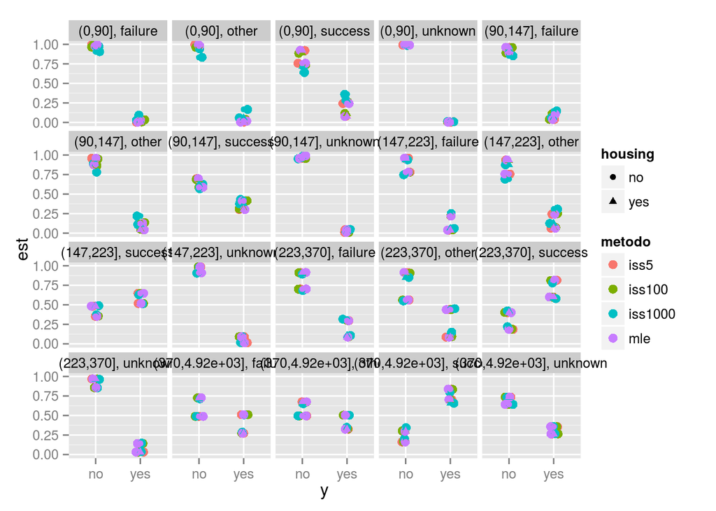

```r
ggplot(probs_l, aes(x = y, y = est, colour = metodo)) +
  geom_jitter(size=3,position=position_jitter(width=0.1, height=0))+
  facet_wrap(~ duration+poutcome) +
  geom_point(aes(shape=housing))
```

Se pueden ver disintas grupaciones, lo cual significa que la estimaciones no difieren mucho entre sí. Debido a esto y a que las diferencias entre los tamaños de muestra imaginario no son muy grandes, nos quedamos con las probabilidades estimadas por el tamaño de muestra más grande ($1000$).

Las comparaciones entre el modelo con muestra imaginaria de $1000$ y con la estimación de máxima verosimilitud se pueden ver en la siguiente gráfica.

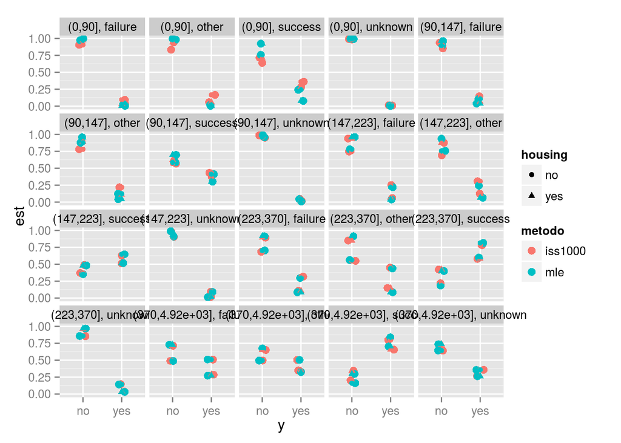

```r
ggplot(probs2_l, aes(x = y, y = est, colour = metodo)) +
  geom_jitter(size=3,position=position_jitter(width=0.1, height=0))+
  facet_wrap(~ duration+poutcome) +
  geom_point(aes(shape=housing))
```

```r
mkt_test$age_cat <- cut(mkt_test$age, quantile(mkt_train$age, probs=(0:15)/15))
mkt_test$balance_cat <- cut(mkt_test$balance, quantile(mkt_train$balance, probs=(0:15)/15))
mkt_test$duration_cat <- cut(mkt_test$duration, quantile(mkt_train$duration, probs=(0:5)/5))
mkt_test$campaign_cat <- cut(mkt_test$campaign, c(0,1,3,max(mkt_train$campaign)))
mkt_test$previous_cat <- factor(mkt_test$previous!=0)
test <- mkt_test[,sapply(mkt_test, class)=='factor']
names(test) <- c("job","marital","education","default","housing","loan","contact","month","poutcome","y",  "age","balance", "duration","campaign","previous")
test <- train[complete.cases(test),]
net<-compile(as.grain(fit3))
pred <- predict.grain(net, 'y', names(train)[-10],test)
```

Vemos la matriz de confusión de la predicción, y el estadístico *kappa* de Cohen.

```r
pred_1 <- factor(pred$pred$y)
levels(pred_1)<-c(0,1)
obs<-factor(test$y)
levels(obs) <- c(0,1)
cm <- confusion.matrix(obs, pred_1)
cm
```

```
##     obs
## pred     0    1
##    0 26090 2792
##    1   365  731
## attr(,"class")
## [1] "confusion.matrix"
```

```r
Kappa(cm)
```

```
## [1] 0.2761494
```

Se puede ver en la matriz de confusión que la predicción está muy cargada hacia los $0$’s, es decir, a rechazar la oferta. Esto tiene sentido pues la proporción de $0$’s en la muestra es mucho mayor comparada a la de $1$’s. Se puede ver la proporción en la siguiente tabla.

```r
prop.table(table(obs))
```

```
## obs
##         0         1
## 0.8824805 0.1175195
```

Repetiremos la predicción anterior, pero ahora usando las estimaciones de máxima verosimilitud.

```r
net_mle<-compile(as.grain(fit_mle))
pred_mle <- predict.grain(net_mle, 'y', names(train)[-10],test)
pred_1_mle <- factor(pred_mle$pred$y)
levels(pred_1_mle)<-c(0,1)
cm2 <- confusion.matrix(obs, pred_1_mle)
cm2
```

```
##     obs
## pred     0    1
##    0 26090 2792
##    1   365  731
## attr(,"class")
## [1] "confusion.matrix"
```

```r
Kappa(cm2)
```

```
## [1] 0.2761494
```

```r
write.net(file = './fit3.net', fit3)
```

Vemos que las estimaciones son muy parecidas. Esto se debe a que las estimaciones de máxima verosimilitud y con *iss* son muy parecidas también, para términos prácticos son iguales. Con ambos métodos, del conjunto de personas con resultado positivo clasificamos correctamente el 20.75%.

Probamos ahora algunos *queries* de probabilidad condicional.

```r
query_1 <- setEvidence(net, nodes = c('y'), states = c('yes'))
querygrain(query_1)
```

```
## $job
## job
##        admin.   blue-collar  entrepreneur     housemaid    management
##    0.11019793    0.18868192    0.03346773    0.03336757    0.21288476
##       retired self-employed      services       student    technician
##    0.06221489    0.03713671    0.08464989    0.02573909    0.16679042
##    unemployed       unknown
##    0.03396154    0.01090755
##
## $housing
## housing
##        no       yes
## 0.6111284 0.3888716
##
## $age
## age
##    (18,27]    (27,30]    (30,31]    (31,33]    (33,35]    (35,36]
## 0.06719194 0.08339552 0.04370796 0.08294070 0.07845631 0.03877016
##    (36,38]    (38,40]    (40,42]    (42,45]    (45,48]    (48,51]
## 0.06582091 0.06045803 0.05411362 0.07581106 0.07463475 0.06512012
##    (51,54]    (54,58]    (58,95]
## 0.06215208 0.07623160 0.07119523
##
## $marital
## marital
##  divorced   married    single
## 0.1214732 0.5945120 0.2840148
##
## $education
## education
##    primary  secondary   tertiary    unknown
## 0.15384755 0.49648513 0.30134205 0.04832527
##
## $balance
## balance
##     (-8.02e+03,-69]             (-69,0]              (0,23]
##          0.05764088          0.09648595          0.04257323
##             (23,92]            (92,175]           (175,270]
##          0.06737534          0.06591993          0.06466576
##           (270,380]           (380,518]           (518,695]
```

[output cut: 32 more lines]

```
##
## $campaign
## campaign
##     (0,1]     (1,3]    (3,58]
## 0.4120678 0.4107515 0.1771807
##
## $contact
## contact
##   cellular  telephone    unknown
## 0.70392825 0.08176108 0.21431067
##
## $default
## default
##         no        yes
## 0.96694087 0.03305913
```

Los queries de probabilidad condicional devueltos por SAMIAM son los siguientes:

P(Y=1)=0.1327  
P(Y=1|Job=Unemployed,marital=Single,Education=Primary)=0.1478  
P(Job=Admin|marital=married,Edu=primary,Balance=1000)=0.0310

El MAP(Maximum a Posteriori) de $Y_i$ obtenido con la evidencia observada E={AGE=20, MARITAL=married, EDUCATION=secondary, DEFAULT=no, BALANCE=1000, MONTH=may, CAMPAIGN=1} es la siguiente

```r
MAP
```

```
##   Variable   Resultado Probabilidad
## 1  contact     unknown       0.5929
## 2 duration     223-370       0.2169
## 3  housing         yes       0.9519
## 4      job blue-collar       0.2513
## 5     loan          no       0.8626
## 6 poutcome     unknown       0.8841
## 7 previous       FALSE       0.8938
## 8        y          no       0.9127
```

Lo anterior se realizo con la funcion MAP de SAMIAM, aunque en estricto sentido el MAP solo devuelve la variable mas probable , no su probabilidad, en la tabla anterior viene la probabilidad solo para darnos una idea de como se comporta.

La probabilidad condicional nos devuelve una probabilidad, mientras que el MAP nos devuelve el nivel de la variable que es más probable con la evidencia conocida.

Asi que la respuesta de cuando utilizar una y cuando utilizar otra varia, es decir, la probabilidad condicional la podemos utilizar para obtener la probabilidad de que un evento suceda. El MAP se refiere a el resultado que es mas probable que suceda con la evidencia observada. Por ejemplo, si queremos encontrar el grupo de personas que es mas probable que vayan a aceptar invertir utilizariamos la primera para condicionar las caracteristicas de las personas que la compañia deberia llamar (el target) para maximizar las inversiones, esto nos daria una probabilidad condicional que deseariamos fuera alta. La segunda la utilizariamos para saber con evidencia dada, cual es el resultado más probable que vamos a obtener para las variables que aun no conocemos.